# Risk Factor Analysis

## Outcome Variable

**Outcome Variable:** whz

## Predictor Variables

**Intervention Variable:** parity

**Adjustment Set:**

- arm
- W_mage
- meducyrs
- feducyrs
- hhwealth_quart
- W_mhtcm
- W_mwtkg
- W_mbmi
- vagbrth
- W_nrooms
- impsan
- delta_W_mage
- delta_meducyrs
- delta_feducyrs
- delta_hhwealth_quart
- delta_W_mhtcm
- delta_W_mwtkg
- delta_W_mbmi
- delta_vagbrth
- delta_W_nrooms
- delta_impsan

## Stratifying Variables

The analysis was stratified on these variable(s):

- agecat
- studyid
- country

## Data Summary

| agecat | studyid | country | parity | n_cell | n | outcome_variable |
| --- | --- | --- | --- | --- | --- | --- |
| Birth | COHORTS | GUATEMALA | 1 | 94 | 756 | whz |
| Birth | COHORTS | GUATEMALA | 2 | 118 | 756 | whz |
| Birth | COHORTS | GUATEMALA | 3+ | 544 | 756 | whz |
| Birth | COHORTS | INDIA | 1 | 641 | 3855 | whz |
| Birth | COHORTS | INDIA | 2 | 982 | 3855 | whz |
| Birth | COHORTS | INDIA | 3+ | 2232 | 3855 | whz |
| Birth | COHORTS | PHILIPPINES | 1 | 640 | 2899 | whz |
| Birth | COHORTS | PHILIPPINES | 2 | 657 | 2899 | whz |
| Birth | COHORTS | PHILIPPINES | 3+ | 1602 | 2899 | whz |
| Birth | GMS-Nepal | NEPAL | 1 | 185 | 641 | whz |
| Birth | GMS-Nepal | NEPAL | 2 | 169 | 641 | whz |
| Birth | GMS-Nepal | NEPAL | 3+ | 287 | 641 | whz |
| Birth | JiVitA-3 | BANGLADESH | 1 | 5520 | 18014 | whz |
| Birth | JiVitA-3 | BANGLADESH | 2 | 6303 | 18014 | whz |
| Birth | JiVitA-3 | BANGLADESH | 3+ | 6191 | 18014 | whz |
| Birth | Keneba | GAMBIA | 1 | 146 | 1338 | whz |
| Birth | Keneba | GAMBIA | 2 | 142 | 1338 | whz |
| Birth | Keneba | GAMBIA | 3+ | 1050 | 1338 | whz |
| Birth | PROVIDE | BANGLADESH | 1 | 202 | 532 | whz |
| Birth | PROVIDE | BANGLADESH | 2 | 182 | 532 | whz |
| Birth | PROVIDE | BANGLADESH | 3+ | 148 | 532 | whz |
| Birth | SAS-CompFeed | INDIA | 1 | 304 | 1103 | whz |
| Birth | SAS-CompFeed | INDIA | 2 | 258 | 1103 | whz |
| Birth | SAS-CompFeed | INDIA | 3+ | 541 | 1103 | whz |
| Birth | ZVITAMBO | ZIMBABWE | 1 | 5561 | 12916 | whz |
| Birth | ZVITAMBO | ZIMBABWE | 2 | 3882 | 12916 | whz |
| Birth | ZVITAMBO | ZIMBABWE | 3+ | 3473 | 12916 | whz |
| 6 months | COHORTS | GUATEMALA | 1 | 132 | 963 | whz |
| 6 months | COHORTS | GUATEMALA | 2 | 139 | 963 | whz |
| 6 months | COHORTS | GUATEMALA | 3+ | 692 | 963 | whz |

[output cut: 57 more lines]

The following strata were considered:

- agecat: 24 months, studyid: COHORTS, country: GUATEMALA
- agecat: 24 months, studyid: COHORTS, country: INDIA
- agecat: 24 months, studyid: COHORTS, country: PHILIPPINES
- agecat: 24 months, studyid: GMS-Nepal, country: NEPAL
- agecat: 24 months, studyid: JiVitA-3, country: BANGLADESH
- agecat: 24 months, studyid: Keneba, country: GAMBIA
- agecat: 24 months, studyid: PROVIDE, country: BANGLADESH
- agecat: 24 months, studyid: TanzaniaChild2, country: TANZANIA, UNITED REPUBLIC OF
- agecat: 24 months, studyid: ZVITAMBO, country: ZIMBABWE
- agecat: 6 months, studyid: COHORTS, country: GUATEMALA
- agecat: 6 months, studyid: COHORTS, country: INDIA
- agecat: 6 months, studyid: COHORTS, country: PHILIPPINES
- agecat: 6 months, studyid: GMS-Nepal, country: NEPAL
- agecat: 6 months, studyid: JiVitA-3, country: BANGLADESH
- agecat: 6 months, studyid: Keneba, country: GAMBIA
- agecat: 6 months, studyid: PROVIDE, country: BANGLADESH
- agecat: 6 months, studyid: SAS-CompFeed, country: INDIA
- agecat: 6 months, studyid: SAS-FoodSuppl, country: INDIA
- agecat: 6 months, studyid: TanzaniaChild2, country: TANZANIA, UNITED REPUBLIC OF
- agecat: 6 months, studyid: ZVITAMBO, country: ZIMBABWE
- agecat: Birth, studyid: COHORTS, country: GUATEMALA
- agecat: Birth, studyid: COHORTS, country: INDIA
- agecat: Birth, studyid: COHORTS, country: PHILIPPINES
- agecat: Birth, studyid: GMS-Nepal, country: NEPAL
- agecat: Birth, studyid: JiVitA-3, country: BANGLADESH
- agecat: Birth, studyid: Keneba, country: GAMBIA
- agecat: Birth, studyid: PROVIDE, country: BANGLADESH
- agecat: Birth, studyid: SAS-CompFeed, country: INDIA
- agecat: Birth, studyid: ZVITAMBO, country: ZIMBABWE

### Dropped Strata

Some strata were dropped due to rare outcomes:

- agecat: 24 months, studyid: TanzaniaChild2, country: TANZANIA, UNITED REPUBLIC OF

## Methods Detail

We’re interested in the causal parameters $E[Y_a]$ for all values of $a \in \mathcal{A}$. These parameters represent the mean outcome if, possibly contrary to fact, we intervened to set all units to have $A=a$. Under the randomization and positivity assumptions, these are identified by the statistical parameters $\psi_a=E_W[E_{Y|A,W}(Y|A=a,W)]$. In addition, we’re interested in the mean of $Y$, $E[Y]$ under no intervention (the observed mean). We will estimate these parameters by using SuperLearner to fit the relevant likelihood factors – $E_{Y|A,W}(Y|A=a,W)$ and $p(A=a|W)$, and then updating our likelihood fit using a joint TMLE.

For unadjusted analyses ($W=\{\}$), initial likelihoods were estimated using Lrnr_glm to estimate the simple $E(Y|A)$ and Lrnr_mean to estimate $p(A)$. For adjusted analyses, a small library containing Lrnr_glmnet, Lrnr_xgboost, and Lrnr_mean was used.

Having estimated these parameters, we will then use the delta method to estimate relative risks and attributable risks relative to a prespecified baseline level of $A$.

# Results Detail

## Results Plots

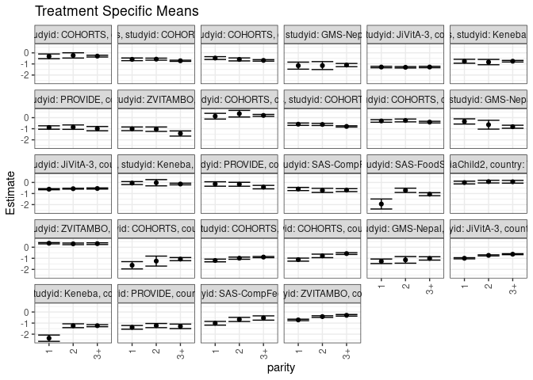

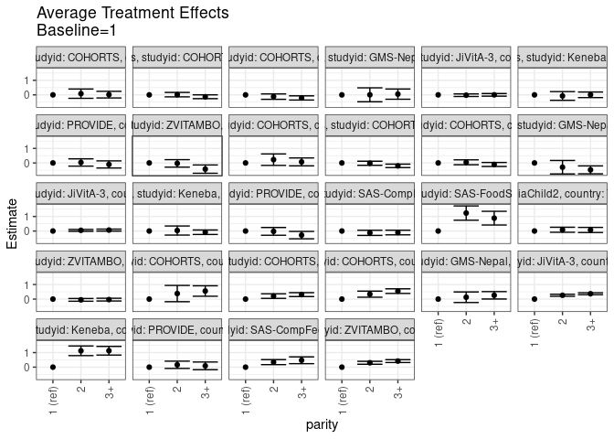

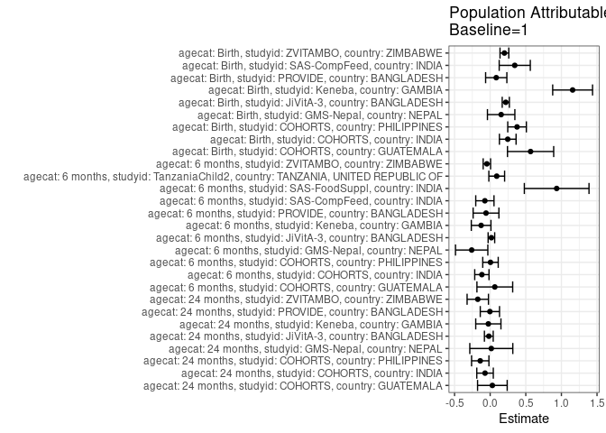

## Results Table

### Parameter: TSM

| agecat | studyid | country | intervention_level | baseline_level | estimate | ci_lower | ci_upper |
| --- | --- | --- | --- | --- | --- | --- | --- |
| Birth | COHORTS | GUATEMALA | 1 | NA | -1.6294458 | -1.9588107 | -1.3000808 |
| Birth | COHORTS | GUATEMALA | 2 | NA | -1.2505809 | -1.6998122 | -0.8013496 |
| Birth | COHORTS | GUATEMALA | 3+ | NA | -1.0741897 | -1.2156206 | -0.9327589 |
| Birth | COHORTS | INDIA | 1 | NA | -1.1964591 | -1.3188944 | -1.0740238 |
| Birth | COHORTS | INDIA | 2 | NA | -0.9889041 | -1.0873332 | -0.8904750 |
| Birth | COHORTS | INDIA | 3+ | NA | -0.8898999 | -0.9442921 | -0.8355077 |
| Birth | COHORTS | PHILIPPINES | 1 | NA | -1.1201940 | -1.2563649 | -0.9840231 |
| Birth | COHORTS | PHILIPPINES | 2 | NA | -0.7837077 | -0.9417903 | -0.6256250 |
| Birth | COHORTS | PHILIPPINES | 3+ | NA | -0.5729942 | -0.6529600 | -0.4930283 |
| Birth | GMS-Nepal | NEPAL | 1 | NA | -1.2706073 | -1.4755074 | -1.0657072 |
| Birth | GMS-Nepal | NEPAL | 2 | NA | -1.1423076 | -1.4419082 | -0.8427070 |
| Birth | GMS-Nepal | NEPAL | 3+ | NA | -1.0104170 | -1.1608261 | -0.8600080 |
| Birth | JiVitA-3 | BANGLADESH | 1 | NA | -0.9970528 | -1.0484893 | -0.9456163 |
| Birth | JiVitA-3 | BANGLADESH | 2 | NA | -0.7354173 | -0.7840259 | -0.6868088 |
| Birth | JiVitA-3 | BANGLADESH | 3+ | NA | -0.6302571 | -0.6742315 | -0.5862828 |
| Birth | Keneba | GAMBIA | 1 | NA | -2.3611917 | -2.6448592 | -2.0775241 |
| Birth | Keneba | GAMBIA | 2 | NA | -1.2388094 | -1.4111663 | -1.0664526 |
| Birth | Keneba | GAMBIA | 3+ | NA | -1.2328876 | -1.3246324 | -1.1411427 |
| Birth | PROVIDE | BANGLADESH | 1 | NA | -1.3835862 | -1.5483523 | -1.2188201 |
| Birth | PROVIDE | BANGLADESH | 2 | NA | -1.2221814 | -1.4096166 | -1.0347462 |
| Birth | PROVIDE | BANGLADESH | 3+ | NA | -1.2935398 | -1.4972728 | -1.0898068 |
| Birth | SAS-CompFeed | INDIA | 1 | NA | -1.0150420 | -1.1829514 | -0.8471327 |
| Birth | SAS-CompFeed | INDIA | 2 | NA | -0.6698803 | -0.8552059 | -0.4845546 |
| Birth | SAS-CompFeed | INDIA | 3+ | NA | -0.5412823 | -0.7353494 | -0.3472152 |
| Birth | ZVITAMBO | ZIMBABWE | 1 | NA | -0.7155182 | -0.7818583 | -0.6491780 |
| Birth | ZVITAMBO | ZIMBABWE | 2 | NA | -0.4153977 | -0.4913223 | -0.3394731 |
| Birth | ZVITAMBO | ZIMBABWE | 3+ | NA | -0.2982990 | -0.3692721 | -0.2273260 |
| 6 months | COHORTS | GUATEMALA | 1 | NA | 0.1290676 | -0.1287037 | 0.3868389 |
| 6 months | COHORTS | GUATEMALA | 2 | NA | 0.3550998 | 0.0570264 | 0.6531732 |
| 6 months | COHORTS | GUATEMALA | 3+ | NA | 0.2008354 | 0.1119847 | 0.2896862 |

[output cut: 54 more lines]

### Parameter: E(Y)

| agecat | studyid | country | intervention_level | baseline_level | estimate | ci_lower | ci_upper |
| --- | --- | --- | --- | --- | --- | --- | --- |
| Birth | COHORTS | GUATEMALA | NA | NA | -1.0621429 | -1.1631387 | -0.9611471 |
| Birth | COHORTS | INDIA | NA | NA | -0.9498080 | -0.9874148 | -0.9122013 |
| Birth | COHORTS | PHILIPPINES | NA | NA | -0.7427251 | -0.7890855 | -0.6963647 |
| Birth | GMS-Nepal | NEPAL | NA | NA | -1.1164431 | -1.2040134 | -1.0288728 |
| Birth | JiVitA-3 | BANGLADESH | NA | NA | -0.7778272 | -0.7968313 | -0.7588232 |
| Birth | Keneba | GAMBIA | NA | NA | -1.2037220 | -1.2694226 | -1.1380213 |
| Birth | PROVIDE | BANGLADESH | NA | NA | -1.2984586 | -1.3752758 | -1.2216415 |
| Birth | SAS-CompFeed | INDIA | NA | NA | -0.6700453 | -0.8474950 | -0.4925957 |
| Birth | ZVITAMBO | ZIMBABWE | NA | NA | -0.5156349 | -0.5414936 | -0.4897762 |
| 6 months | COHORTS | GUATEMALA | NA | NA | 0.1940810 | 0.1226351 | 0.2655269 |
| 6 months | COHORTS | INDIA | NA | NA | -0.7068611 | -0.7417800 | -0.6719423 |
| 6 months | COHORTS | PHILIPPINES | NA | NA | -0.2938433 | -0.3352064 | -0.2524802 |
| 6 months | GMS-Nepal | NEPAL | NA | NA | -0.6038416 | -0.6899448 | -0.5177384 |
| 6 months | JiVitA-3 | BANGLADESH | NA | NA | -0.5935161 | -0.6130518 | -0.5739805 |
| 6 months | Keneba | GAMBIA | NA | NA | -0.1873900 | -0.2456638 | -0.1291162 |
| 6 months | PROVIDE | BANGLADESH | NA | NA | -0.1990907 | -0.2817968 | -0.1163845 |
| 6 months | SAS-CompFeed | INDIA | NA | NA | -0.6657084 | -0.8024377 | -0.5289791 |
| 6 months | SAS-FoodSuppl | INDIA | NA | NA | -1.0121579 | -1.1280429 | -0.8962729 |
| 6 months | TanzaniaChild2 | TANZANIA, UNITED REPUBLIC OF | NA | NA | 0.0797179 | 0.0266621 | 0.1327737 |
| 6 months | ZVITAMBO | ZIMBABWE | NA | NA | 0.3106432 | 0.2849661 | 0.3363203 |
| 24 months | COHORTS | GUATEMALA | NA | NA | -0.2813755 | -0.3354674 | -0.2272835 |
| 24 months | COHORTS | INDIA | NA | NA | -0.6564729 | -0.6914450 | -0.6215007 |
| 24 months | COHORTS | PHILIPPINES | NA | NA | -0.6099592 | -0.6467541 | -0.5731643 |
| 24 months | GMS-Nepal | NEPAL | NA | NA | -1.1363107 | -1.2252817 | -1.0473398 |
| 24 months | JiVitA-3 | BANGLADESH | NA | NA | -1.2978031 | -1.3210763 | -1.2745298 |
| 24 months | Keneba | GAMBIA | NA | NA | -0.7834078 | -0.8357743 | -0.7310414 |
| 24 months | PROVIDE | BANGLADESH | NA | NA | -0.8928670 | -0.9755153 | -0.8102187 |
| 24 months | ZVITAMBO | ZIMBABWE | NA | NA | -1.1817824 | -1.2809226 | -1.0826422 |

### Parameter: ATE

| agecat | studyid | country | intervention_level | baseline_level | estimate | ci_lower | ci_upper |
| --- | --- | --- | --- | --- | --- | --- | --- |
| Birth | COHORTS | GUATEMALA | 1 | 1 | 0.0000000 | 0.0000000 | 0.0000000 |
| Birth | COHORTS | GUATEMALA | 2 | 1 | 0.3788648 | -0.1785414 | 0.9362711 |
| Birth | COHORTS | GUATEMALA | 3+ | 1 | 0.5552561 | 0.1963689 | 0.9141432 |
| Birth | COHORTS | INDIA | 1 | 1 | 0.0000000 | 0.0000000 | 0.0000000 |
| Birth | COHORTS | INDIA | 2 | 1 | 0.2075550 | 0.0503962 | 0.3647138 |
| Birth | COHORTS | INDIA | 3+ | 1 | 0.3065592 | 0.1725797 | 0.4405388 |
| Birth | COHORTS | PHILIPPINES | 1 | 1 | 0.0000000 | 0.0000000 | 0.0000000 |
| Birth | COHORTS | PHILIPPINES | 2 | 1 | 0.3364863 | 0.1277770 | 0.5451956 |
| Birth | COHORTS | PHILIPPINES | 3+ | 1 | 0.5471998 | 0.3890628 | 0.7053369 |
| Birth | GMS-Nepal | NEPAL | 1 | 1 | 0.0000000 | 0.0000000 | 0.0000000 |
| Birth | GMS-Nepal | NEPAL | 2 | 1 | 0.1282997 | -0.2344604 | 0.4910597 |
| Birth | GMS-Nepal | NEPAL | 3+ | 1 | 0.2601903 | 0.0060120 | 0.5143685 |
| Birth | JiVitA-3 | BANGLADESH | 1 | 1 | 0.0000000 | 0.0000000 | 0.0000000 |
| Birth | JiVitA-3 | BANGLADESH | 2 | 1 | 0.2616355 | 0.1908169 | 0.3324541 |
| Birth | JiVitA-3 | BANGLADESH | 3+ | 1 | 0.3667957 | 0.3000242 | 0.4335672 |
| Birth | Keneba | GAMBIA | 1 | 1 | 0.0000000 | 0.0000000 | 0.0000000 |
| Birth | Keneba | GAMBIA | 2 | 1 | 1.1223822 | 0.7912758 | 1.4534887 |
| Birth | Keneba | GAMBIA | 3+ | 1 | 1.1283041 | 0.8294302 | 1.4271780 |
| Birth | PROVIDE | BANGLADESH | 1 | 1 | 0.0000000 | 0.0000000 | 0.0000000 |
| Birth | PROVIDE | BANGLADESH | 2 | 1 | 0.1614048 | -0.0882781 | 0.4110877 |
| Birth | PROVIDE | BANGLADESH | 3+ | 1 | 0.0900464 | -0.1722204 | 0.3523132 |
| Birth | SAS-CompFeed | INDIA | 1 | 1 | 0.0000000 | 0.0000000 | 0.0000000 |
| Birth | SAS-CompFeed | INDIA | 2 | 1 | 0.3451618 | 0.1721253 | 0.5181983 |
| Birth | SAS-CompFeed | INDIA | 3+ | 1 | 0.4737598 | 0.2409037 | 0.7066158 |
| Birth | ZVITAMBO | ZIMBABWE | 1 | 1 | 0.0000000 | 0.0000000 | 0.0000000 |
| Birth | ZVITAMBO | ZIMBABWE | 2 | 1 | 0.3001205 | 0.1993356 | 0.4009053 |
| Birth | ZVITAMBO | ZIMBABWE | 3+ | 1 | 0.4172192 | 0.3200953 | 0.5143430 |
| 6 months | COHORTS | GUATEMALA | 1 | 1 | 0.0000000 | 0.0000000 | 0.0000000 |
| 6 months | COHORTS | GUATEMALA | 2 | 1 | 0.2260323 | -0.1671754 | 0.6192400 |
| 6 months | COHORTS | GUATEMALA | 3+ | 1 | 0.0717679 | -0.1996262 | 0.3431620 |

[output cut: 54 more lines]

### Parameter: PAR

| agecat | studyid | country | intervention_level | baseline_level | estimate | ci_lower | ci_upper |
| --- | --- | --- | --- | --- | --- | --- | --- |
| Birth | COHORTS | GUATEMALA | 1 | NA | 0.5673029 | 0.2429937 | 0.8916122 |
| Birth | COHORTS | INDIA | 1 | NA | 0.2466511 | 0.1296177 | 0.3636844 |
| Birth | COHORTS | PHILIPPINES | 1 | NA | 0.3774689 | 0.2467979 | 0.5081399 |
| Birth | GMS-Nepal | NEPAL | 1 | NA | 0.1541642 | -0.0383086 | 0.3466370 |
| Birth | JiVitA-3 | BANGLADESH | 1 | NA | 0.2192256 | 0.1690359 | 0.2694152 |
| Birth | Keneba | GAMBIA | 1 | NA | 1.1574697 | 0.8775770 | 1.4373624 |
| Birth | PROVIDE | BANGLADESH | 1 | NA | 0.0851275 | -0.0638602 | 0.2341153 |
| Birth | SAS-CompFeed | INDIA | 1 | NA | 0.3449967 | 0.1267147 | 0.5632787 |
| Birth | ZVITAMBO | ZIMBABWE | 1 | NA | 0.1998833 | 0.1382272 | 0.2615394 |
| 6 months | COHORTS | GUATEMALA | 1 | NA | 0.0650134 | -0.1859722 | 0.3159991 |
| 6 months | COHORTS | INDIA | 1 | NA | -0.1166713 | -0.2167708 | -0.0165718 |
| 6 months | COHORTS | PHILIPPINES | 1 | NA | 0.0043113 | -0.1042280 | 0.1128507 |
| 6 months | GMS-Nepal | NEPAL | 1 | NA | -0.2596178 | -0.4864510 | -0.0327846 |
| 6 months | JiVitA-3 | BANGLADESH | 1 | NA | 0.0172885 | -0.0288354 | 0.0634123 |
| 6 months | Keneba | GAMBIA | 1 | NA | -0.1269729 | -0.2649945 | 0.0110487 |
| 6 months | PROVIDE | BANGLADESH | 1 | NA | -0.0582507 | -0.2391031 | 0.1226018 |
| 6 months | SAS-CompFeed | INDIA | 1 | NA | -0.0743930 | -0.2025306 | 0.0537446 |
| 6 months | SAS-FoodSuppl | INDIA | 1 | NA | 0.9335564 | 0.4796129 | 1.3874999 |
| 6 months | TanzaniaChild2 | TANZANIA, UNITED REPUBLIC OF | 1 | NA | 0.0919055 | -0.0187961 | 0.2026070 |
| 6 months | ZVITAMBO | ZIMBABWE | 1 | NA | -0.0462521 | -0.0982869 | 0.0057828 |
| 24 months | COHORTS | GUATEMALA | 1 | NA | 0.0308976 | -0.1770378 | 0.2388329 |
| 24 months | COHORTS | INDIA | 1 | NA | -0.0720335 | -0.1879215 | 0.0438544 |
| 24 months | COHORTS | PHILIPPINES | 1 | NA | -0.1394292 | -0.2611790 | -0.0176794 |
| 24 months | GMS-Nepal | NEPAL | 1 | NA | 0.0159403 | -0.2858753 | 0.3177559 |
| 24 months | JiVitA-3 | BANGLADESH | 1 | NA | -0.0190164 | -0.0807593 | 0.0427265 |
| 24 months | Keneba | GAMBIA | 1 | NA | -0.0257614 | -0.2027434 | 0.1512207 |
| 24 months | PROVIDE | BANGLADESH | 1 | NA | -0.0038913 | -0.1390107 | 0.1312282 |
| 24 months | ZVITAMBO | ZIMBABWE | 1 | NA | -0.1740358 | -0.3238804 | -0.0241912 |